## MA2102

# Probability and Statistics

#### Lecture-17(Part-b)

# Some Special Continuous Distributions

Now, we are going to see some most frequently used continuous distributions and describe their important properties.

### (Continuous) Uniform Distributions:

Consider the random experiment of selecting a number at random from the interval $[a,b]$.

Sample space $\Omega=[a,b]$

define, $X:\Omega\to\mathbb{R}$ with mapping $\omega\mapsto \omega$

$S_X=[a,b]$

For $a\le a_1<b_1\le b$, the probability of selecting number in the interval $[a_1,b_1]$ will be proportional to the length of the interval $[a_1,b_1]$

$\therefore$ $P(a_1\le X \le b_1])=k(b_1-a_1)$ (where $k$ is proportional to constant)

and $P(a\le X\le b)=P(\Omega)=1$ ($\therefore$ Axiom (2))

$P(a\le X \le b)=1\Rightarrow k(b-a)=1\Rightarrow k=\frac{1}{b-a}$

$\therefore$ $P(a_1\le X \le b_1)=\frac{b_1-a_1}{b-a}$ for $a\le a_1<b_1\le b$

For $x<a$, $F_X(x)=P(X\le x)=0$

For $a\le x<b$, $F_X(x)=P(X\le x)=P(-\infty<X<a)+P(a\le X\le x)=0+\frac{x-a}{b-a}=\frac{x-a}{b-a}$

For $x\ge b$, $F_X(x)=P(X\le x)=P(-\infty<X<a)+P(a\le X\le b)+P(b<X\le x)=0+\frac{b-a}{b-a}+0=1$

$F_X(x)=\left\{\begin{matrix} 0&x<a \\ \frac{x-a}{b-a}&a\le x < b\\ 1& x\ge b \end{matrix}\right.$

and $PDF$ of $X$, $f_X(x)=\frac{d}{dx}F_X(x)=\left\{\begin{matrix} \frac{1}{b-a} & a\le x\le b \\ 0 & \text{otherwise} \end{matrix}\right.$

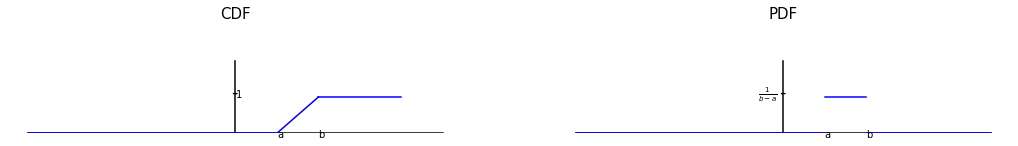

```python
import matplotlib.pyplot as plt
import numpy as np

fig,ax = plt.subplots(1,2,figsize=(18,2))
#Example Uniform CDF Graph
ax[0].set_title("CDF",fontsize=15,color='black')
ax[0].plot([-5,5],[0,0],color='black') # x-axis
ax[0].plot([0,0],[0,2],color='black') # y-axis
ax[0].plot([-5,1],[0,0],color='b')
ax[0].plot([1,2],[0,1],color='b')
ax[0].plot([2,4],[1,1],color='b')
ax[0].text(1,-0.1,"a")
ax[0].text(2,-0.1,"b")
ax[0].text(0,1,"1")
ax[0].text(-0.1,1,"-",fontsize=18)
ax[0].set_ylim(0,3)
ax[0].axis('off')

#Example Uniform PDF Graph
ax[1].set_title("PDF",fontsize=15,color='black')
ax[1].plot([-5,5],[0,0],color='black') # x-axis
ax[1].plot([0,0],[0,2],color='black') # y-axis
ax[1].plot([-5,1],[0,0],color='b')
ax[1].plot([1,2],[1,1],color='b')
ax[1].plot([2,5],[0,0],color='b')
ax[1].text(1,-0.1,"a")
ax[1].text(2,-0.1,"b")
ax[1].text(-0.6,1,r"$\frac{1}{b-a}$")
ax[1].text(-0.1,1,"-",fontsize=18)
ax[1].set_ylim(0,3)
ax[1].axis('off')
plt.show()
```

Here the $PDF$ of $X$, $f_X(x)$ is constant over $[a,b]$. That means, $X$ is just likely to be near any value in $[a,b]$ as any other value.

($\because$ $f(x)$ is the measure of likelihood of $X$ being around $x$)

Here $X$ is said to have **Uniform Distribution** over interval $[a,b]$ and $a,b$ are parameters for this distribution.

**Notation:** $X\sim U[a,b]$

$M.G.F:$ $M_X(t)=\left\{\begin{matrix} \frac{e^{tb}-e^{ta}}{t(b-a)}& t\ne 0 \\ 1& t=0 \end{matrix}\right.$

$E(X)=\frac{a+b}{2}$, $Var(X)=\frac{(b-a)^2}{12}$, and $E(X^k)=\frac{b^{k+1}-a^{k+1}}{(k+1)(b-a)}$, for $k=1,2,3,...$

**Example:** Buses arrive at a specified stop at 15 minute intervals starting at 7 am. That is, they arrive at 7:00,7:15,7:30,7:45 and so on. If a passenger arrives at a stop at a time that is uniformly distributed between 7 and 7:30, then find the probability that he waits  
(a) Less than 5 minutes for bus  
(b) More than 10 minutes for bus

*solution:* Let $X$ denote the time(in minutes) past $7:00$ am that passenger arrives at the stop.

$X\sim U[0,30]$

$f_X(x)=\left\{\begin{matrix} \frac{1}{30}& 0\le x\le 30 \\ 0 & \text{otherwise} \end{matrix}\right.$, $F_X(x)=\left\{\begin{matrix} 0&x<0 \\ \frac{x}{30}& 0\le x<30 \\ 1& x\ge 30 \end{matrix}\right.$

(a) Let $A$ be the event that passenger will have to wait less than 5 minutes

$A$ happens $\iff$ ($10<X<15$) or ($25<X<30$)

$P(A)=P(10<X<15)+P(25<X<30)=\int_{10}^{15}\frac{1}{30}dx+\int_{25}^{30}\frac{1}{30}dx=\frac{15-10}{30}+\frac{30-25}{30}=\frac{1}{3}$

$\therefore$ $P(A)=\frac{1}{3}$

(b) Let $B$ be the event that passenger will have to wait more than 10 minutes for bus.

$B$ happens $\iff$ ($0<X<5$) or ($15<X<20$)

$P(B)=P(0<X<5)+P(15<X<20)=(F_X(5)-F_X(0))+(F_X(20)-F_X(15))=(\frac{5}{30}-\frac{0}{30})+(\frac{20}{30}-\frac{15}{30})=\frac{5}{30}+\frac{5}{30}=\frac{1}{3}$

### Erlang Distribution:

Consider a Poisson process with rate parameter $\lambda0$ (i.e $\lambda=$ average number of event occurrences in unit time interval)

Let $X_t$ denote the number of event occurrences in the interval $[0,t]$

then average number of occurrences in the interval $[0,t]=\lambda t$

$\therefore$ $X_t\sim Poisson(\lambda t)$ ($\because$ Think of $[0,t]$ as unit time interval)

$P(X_t=k)=\frac{e^{-\lambda t}(\lambda t)^k}{k!}$ for $k=0,1,2,3,...$

Let $T_r$ denote the time taken for the $r^{th}$ event occurrence,(Here $r$ is positive integer)

$CDF$ of $T_r$, $F_{T_r}(t)=P(T_r\le t)$

for $t<0$, $F_{T_r}(t)=0$

for $t>0$, $F_{T_r}(t)=P(T_r\le t)$

$=1-P(T_r>t)$

$=1-P(X_t\le r-1)$

$F_{T_r}(t)=1-\sum_{k=0}^{r-1}\frac{e^{-\lambda t}(\lambda t)^k}{k!}$

$\therefore$ $F_{T_r}(t)=\left\{\begin{matrix} 1-e^{-\lambda t}-\sum_{k=1}^{r-1}\frac{e^{-\lambda t}(\lambda t)^k}{k!}& t>0\\ 0& t\le 0 \end{matrix}\right.$

$PDF$ of $T_r$, $f_{T_r}(t)=\frac{d}{dt}\left(F_{T_r}(t)\right)$

$=\frac{d}{dt}\left(1-e^{-\lambda t}-\sum_{k=1}^{r-1}\frac{e^{-\lambda t}(\lambda t)^k}{k!}\right)$

$=\left(0+\lambda e^{-\lambda t}-\sum_{k=1}^{r-1}\frac{d}{dt}\left(\frac{e^{-\lambda t}(\lambda t)^k}{k!}\right)\right)$

$=\left(\lambda e^{-\lambda t}-\sum_{k=1}^{r-1}\left[\frac{e^{-\lambda t}k(\lambda t)^{k-1}(\lambda)}{k!}+\frac{e^{-\lambda t}(-\lambda )(\lambda t)^k}{k!}\right]\right)$

$=\lambda e^{-\lambda t}\left(1-\sum_{k=1}^{r-1}\left[\frac{(\lambda t)^{k-1}}{(k-1)!}-\frac{(\lambda t)^k}{k!}\right]\right)=\lambda e^{-\lambda t}\frac{(\lambda t)^{r-1}}{(r-1)!}$

Here $T_r$ is said to have **Erlang Distribution** with rate parameter $\lambda$, and shape parameter $r$. This is a special case of **Gamma Distribution**. We can rewrite the $PDF$ of $T_r$ in the following form.

$f_{T_r}=\left\{\begin{matrix} \frac{\lambda e^{-\lambda t}(\lambda t)^{r-1}}{\Gamma(r)}& t>0\\ 0& t\le 0 \end{matrix}\right.$

### Gamma Distribution:

A random variable $X$ is said to have a **Gamma Distribution** with *rate parameter* $\lambda >0$, and *shape parameter* $\alpha >0$, if its $PDF$ is given by

$f_X(x)=\left\{\begin{matrix} \frac{\lambda e^{-\lambda x}(\lambda x)^{\alpha -1}}{\Gamma(\alpha)}& x>0 \\ 0& x\le 0 \end{matrix}\right.$

**Notation:** $X\sim Gamma(\alpha,\lambda)$

$E(X)=\frac{\alpha}{\lambda}$, $Var(X)=\frac{\alpha}{\lambda^2}$

$MGF:$ $M_X(t)=\left(\frac{\lambda}{\lambda-t}\right)^\alpha$, $-\lambda<t<\lambda$

**Exercise:** If $X\sim Gamma(\alpha,\lambda)$ , then show that $\mu=\frac{\alpha}{\lambda}$, $\sigma^2=\frac{\alpha}{\lambda^2}$ through its $MGF$

$\left[\text{Hint}: \mu=M_X^{(1)}(0),~~ \sigma^2=M_X^{(2)}(0)-\left(M_X^{(1)}(0)\right)^2\right]$

```python
%matplotlib inline
import math
import numpy as np
import matplotlib.pyplot as plt
from ipywidgets import interact ,interactive, fixed, interact_manual
import ipywidgets as widgets

Infty0=100

def GammaPDFGraph(alpa,lamda):
    #fig, ax = plt.subplots()
    x=np.linspace(0,Infty0,10000)
    fig = plt.figure(figsize=(12,8))
    ax=fig.add_subplot(111)
    ax.plot(x,(lamda*np.exp(-lamda*x)*(lamda*x)**(alpa-1))/math.gamma(alpa))
    ax.set_title("Gamma Distribution")
    ax.set_xlabel("$x$")
    ax.set_ylabel("$f_X(x)$")
    ax.set_yticks([0,0.2,0.4,0.6,0.8,1])
    ax.set_xlim(0,Infty0)
    ax.set_ylim(0,1)
    plt.show()


# Please Click the Run Interact Button to see the PDF graph
interactive(GammaPDFGraph,{'manual':True},alpa=widgets.FloatSlider(min=0.25, max=50, step=0.25, value=1,description=r'$\alpha$ :'),lamda=widgets.FloatSlider(min=0.1, max=5, step=0.5, value=2,description=r'$\lambda$:'))
#interactive(GammaPDFGraph,{'manual':False},alpa=widgets.FloatSlider(min=0.25, max=50, step=0.25, value=1,description=r'$\alpha$ :'),lamda=widgets.FloatSlider(min=0.1, max=5, step=0.5, value=2,description=r'$\lambda$:'))
```

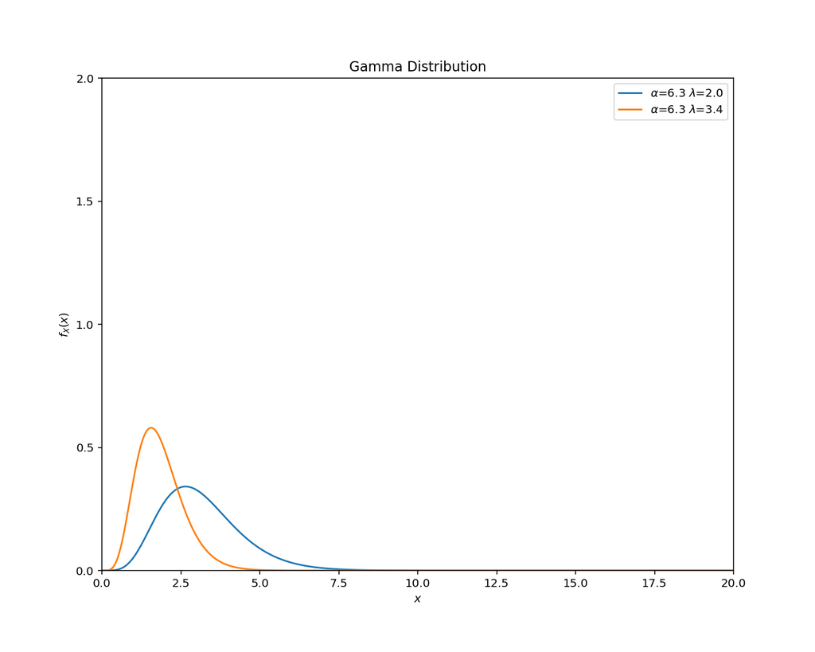

```python
import math
import numpy as np
import matplotlib.pyplot as plt
from ipywidgets import interact ,interactive, fixed, interact_manual
import ipywidgets as widgets
%matplotlib nbagg


def GammaPDFGraph(alpa,lamda):
    plt.plot(x,(lamda*np.exp(-lamda*x)*(lamda*x)**(alpa-1))/math.gamma(alpa),label=r"$\alpha$={0} $\lambda$={1}".format(alpa,lamda))
    plt.legend(loc='upper right')


Infty0=100
x=np.linspace(0,Infty0,10000)
plt.figure(figsize=(10,8))
plt.title("Gamma Distribution")
plt.xlabel("$x$")
plt.ylabel("$f_X(x)$")
plt.yticks([0,0.5,1,1.5,2])
plt.xlim(0,20)
plt.ylim(0,2)
plt.show()

#interact(GammaPDFGraph,alpa=widgets.FloatSlider(min=0.5, max=50, step=0.5, value=1,description=r'$\alpha$ :'),lamda=widgets.FloatSlider(min=0.5, max=5, step=0.5, value=2,description=r'$\lambda$:'))
interactive(GammaPDFGraph,{'manual':True},alpa=widgets.FloatSlider(min=0.1, max=40, step=0.1, value=2,description=r'$\alpha$ :'),lamda=widgets.FloatSlider(min=0.1, max=10, step=0.1, value=2,description=r'$\lambda$:'))
```

**Problem:** The CPU time requirement $T$ for jobs has a Gamma distribution with mean $\mu=40$ seconds, and standard deviation $\sigma=20$ seconds.A job taken less than 20 seconds is a shorter job. What is the probability that of 5 randomly selected jobs, at least 2 are short jobs.

*solution:* Here $T\sim Gamma(\alpha,\lambda)$, $\mu=\frac{\alpha}{\lambda}=40$----(1), and $\sigma^2=\frac{\alpha}{\lambda^2}=(20)^2$----(2) ($\because$ $\sigma=20$)

(1)/(2) $\Rightarrow$ $\frac{\frac{\alpha}{\lambda}}{\frac{\alpha}{\lambda^2}}=\frac{40}{400}\Rightarrow \lambda=\frac{1}{10}$

(1)$\Rightarrow$ $\frac{\alpha}{\frac{1}{10}}=40\Rightarrow \alpha=4$

$\therefore$ $T\sim Gamma(4,\frac{1}{10})$

$f_T(t)=\left\{\begin{matrix} \frac{\frac{1}{10}\left(\frac{t}{10}\right)^{3}e^{-\frac{t}{10}}}{3!}& t>0\\ 0& t\le 0 \end{matrix}\right.$

Let $A$ be the event that a randomly selected job is short job.

Let $p=P(A)=P(T<20)=\frac{1}{60}\int_{0}^{20}\left(\frac{t}{10}\right)^3e^{-\frac{t}{10}}dt$

Take $y=\frac{t}{10}\Rightarrow$ $dy=\frac{dt}{10}$ and $y$ limits from 0 to 2

$p=\frac{1}{6}\int_{0}^{2}y^3e^{-y}dy=\frac{1}{6}\int_{0}^{2}y^3d(-e^{-y})$

$=\frac{1}{6}\left[\left[y^3(-e^{-y})\right]_{0}^{2}-\int_{0}^{2}(-e^{-y})3y^2dy\right]$ $\left[\therefore\int_{a}^{b}udv=[uv]_{a}^{b}-\int_{a}^{b}vdu\right]$

$=\frac{1}{6}\left[2^3\left[-e^{-2}-0\right]+3\int_{0}^{2}y^2d(-e^{-y})dy\right]$

$=\frac{-8}{6e^2}+\frac{3}{6}\left(\left[y^2(-e^{-y})\right]_{0}^{2}-\int_{0}^{2}(-e^{-y}2y dy)\right)$

$=\frac{-4}{3e^2}+\frac{1}{2}\left(\left[2^2(-e^{-2}-0)+2\int_{0}^{2}yd(-e^{-y})\right]\right)$

$=\frac{-4}{3e^2}-\frac{2}{e^2}+\left[y(-e^{-y})\right]_{0}^{2}-\int_{0}^{2}(-e^{-y}dy)$

$=\frac{-4}{3e^2}-\frac{2}{e^2}+\left[2(-e^{-y}-0)\right]+\left[-e^{-y}\right]_{0}^{2}$

$=\frac{-4}{3e^2}-\frac{2}{e^2}-\frac{2}{e^2}+\left[-e^{-2}+1\right]$

$=1-\frac{4}{3e^2}-\frac{5}{e^2}=1-\frac{1}{e^2}\left(\frac{4+15}{3}\right)=1-\frac{19}{3e^2}=0.1428765$

Let $X=$ number of short jobs out of 5 jobs, then $X\sim Bin(5,0.1428)$

Here we are interested in $P(X\ge 2)=?$

$P(X\ge 2)=1-P(X<2)=1-P(X=0)-P(X=1)$

$=1-\binom{5}{0}(0.1428)^0(1-0.1428)^5-\binom{5}{1}(0.1428)^1(1-0.1428)^4\approx0.1519$

$\therefore$ $P(X\ge 2)=0.1519$